# HOUSE PRICE ESTIMATION

```python
import pandas as pd
import matplotlib.pyplot as plt
import seaborn as sns
import numpy as np
from scipy.stats import norm
from sklearn.preprocessing import StandardScaler
from scipy import stats
import warnings
warnings.filterwarnings('ignore')
%matplotlib inline
import matplotlib
matplotlib.rcParams['figure.figsize'] = [10.0, 10.0]
```

The goal of our project - given descriptive parameters, predict the price of a house. We use data from a Kaggle competition "House Prices: Advanced Regression techniques": a modernized and expanded version of the often cited Boston Housing dataset. Let's explore the data first.

## Exploratory Data Analysis

```python
train_data = pd.read_csv('C:/Users/trety/Downloads/train.csv')
train_data.columns
```

```
Index(['Id', 'MSSubClass', 'MSZoning', 'LotFrontage', 'LotArea', 'Street',
       'Alley', 'LotShape', 'LandContour', 'Utilities', 'LotConfig',
       'LandSlope', 'Neighborhood', 'Condition1', 'Condition2', 'BldgType',
       'HouseStyle', 'OverallQual', 'OverallCond', 'YearBuilt', 'YearRemodAdd',
       'RoofStyle', 'RoofMatl', 'Exterior1st', 'Exterior2nd', 'MasVnrType',
       'MasVnrArea', 'ExterQual', 'ExterCond', 'Foundation', 'BsmtQual',
       'BsmtCond', 'BsmtExposure', 'BsmtFinType1', 'BsmtFinSF1',
       'BsmtFinType2', 'BsmtFinSF2', 'BsmtUnfSF', 'TotalBsmtSF', 'Heating',
       'HeatingQC', 'CentralAir', 'Electrical', '1stFlrSF', '2ndFlrSF',
       'LowQualFinSF', 'GrLivArea', 'BsmtFullBath', 'BsmtHalfBath', 'FullBath',
       'HalfBath', 'BedroomAbvGr', 'KitchenAbvGr', 'KitchenQual',
       'TotRmsAbvGrd', 'Functional', 'Fireplaces', 'FireplaceQu', 'GarageType',
       'GarageYrBlt', 'GarageFinish', 'GarageCars', 'GarageArea', 'GarageQual',
       'GarageCond', 'PavedDrive', 'WoodDeckSF', 'OpenPorchSF',
       'EnclosedPorch', '3SsnPorch', 'ScreenPorch', 'PoolArea', 'PoolQC',
       'Fence', 'MiscFeature', 'MiscVal', 'MoSold', 'YrSold', 'SaleType',
       'SaleCondition', 'SalePrice'],
      dtype='object')
```

```python
train_data.head(5)
```

|  | Id | MSSubClass | MSZoning | LotFrontage | LotArea | Street | Alley | LotShape | LandContour | Utilities | ... | PoolArea | PoolQC | Fence | MiscFeature | MiscVal | MoSold | YrSold | SaleType | SaleCondition | SalePrice |
| --- | --- | --- | --- | --- | --- | --- | --- | --- | --- | --- | --- | --- | --- | --- | --- | --- | --- | --- | --- | --- | --- |
| 0 | 1 | 60 | RL | 65.0 | 8450 | Pave | NaN | Reg | Lvl | AllPub | ... | 0 | NaN | NaN | NaN | 0 | 2 | 2008 | WD | Normal | 208500 |
| 1 | 2 | 20 | RL | 80.0 | 9600 | Pave | NaN | Reg | Lvl | AllPub | ... | 0 | NaN | NaN | NaN | 0 | 5 | 2007 | WD | Normal | 181500 |
| 2 | 3 | 60 | RL | 68.0 | 11250 | Pave | NaN | IR1 | Lvl | AllPub | ... | 0 | NaN | NaN | NaN | 0 | 9 | 2008 | WD | Normal | 223500 |
| 3 | 4 | 70 | RL | 60.0 | 9550 | Pave | NaN | IR1 | Lvl | AllPub | ... | 0 | NaN | NaN | NaN | 0 | 2 | 2006 | WD | Abnorml | 140000 |
| 4 | 5 | 60 | RL | 84.0 | 14260 | Pave | NaN | IR1 | Lvl | AllPub | ... | 0 | NaN | NaN | NaN | 0 | 12 | 2008 | WD | Normal | 250000 |

5 rows × 81 columns

```python
train_data.describe()
```

|  | Id | MSSubClass | LotFrontage | LotArea | OverallQual | OverallCond | YearBuilt | YearRemodAdd | MasVnrArea | BsmtFinSF1 | ... | WoodDeckSF | OpenPorchSF | EnclosedPorch | 3SsnPorch | ScreenPorch | PoolArea | MiscVal | MoSold | YrSold | SalePrice |
| --- | --- | --- | --- | --- | --- | --- | --- | --- | --- | --- | --- | --- | --- | --- | --- | --- | --- | --- | --- | --- | --- |
| count | 1460.000000 | 1460.000000 | 1201.000000 | 1460.000000 | 1460.000000 | 1460.000000 | 1460.000000 | 1460.000000 | 1452.000000 | 1460.000000 | ... | 1460.000000 | 1460.000000 | 1460.000000 | 1460.000000 | 1460.000000 | 1460.000000 | 1460.000000 | 1460.000000 | 1460.000000 | 1460.000000 |
| mean | 730.500000 | 56.897260 | 70.049958 | 10516.828082 | 6.099315 | 5.575342 | 1971.267808 | 1984.865753 | 103.685262 | 443.639726 | ... | 94.244521 | 46.660274 | 21.954110 | 3.409589 | 15.060959 | 2.758904 | 43.489041 | 6.321918 | 2007.815753 | 180921.195890 |
| std | 421.610009 | 42.300571 | 24.284752 | 9981.264932 | 1.382997 | 1.112799 | 30.202904 | 20.645407 | 181.066207 | 456.098091 | ... | 125.338794 | 66.256028 | 61.119149 | 29.317331 | 55.757415 | 40.177307 | 496.123024 | 2.703626 | 1.328095 | 79442.502883 |
| min | 1.000000 | 20.000000 | 21.000000 | 1300.000000 | 1.000000 | 1.000000 | 1872.000000 | 1950.000000 | 0.000000 | 0.000000 | ... | 0.000000 | 0.000000 | 0.000000 | 0.000000 | 0.000000 | 0.000000 | 0.000000 | 1.000000 | 2006.000000 | 34900.000000 |
| 25% | 365.750000 | 20.000000 | 59.000000 | 7553.500000 | 5.000000 | 5.000000 | 1954.000000 | 1967.000000 | 0.000000 | 0.000000 | ... | 0.000000 | 0.000000 | 0.000000 | 0.000000 | 0.000000 | 0.000000 | 0.000000 | 5.000000 | 2007.000000 | 129975.000000 |
| 50% | 730.500000 | 50.000000 | 69.000000 | 9478.500000 | 6.000000 | 5.000000 | 1973.000000 | 1994.000000 | 0.000000 | 383.500000 | ... | 0.000000 | 25.000000 | 0.000000 | 0.000000 | 0.000000 | 0.000000 | 0.000000 | 6.000000 | 2008.000000 | 163000.000000 |
| 75% | 1095.250000 | 70.000000 | 80.000000 | 11601.500000 | 7.000000 | 6.000000 | 2000.000000 | 2004.000000 | 166.000000 | 712.250000 | ... | 168.000000 | 68.000000 | 0.000000 | 0.000000 | 0.000000 | 0.000000 | 0.000000 | 8.000000 | 2009.000000 | 214000.000000 |
| max | 1460.000000 | 190.000000 | 313.000000 | 215245.000000 | 10.000000 | 9.000000 | 2010.000000 | 2010.000000 | 1600.000000 | 5644.000000 | ... | 857.000000 | 547.000000 | 552.000000 | 508.000000 | 480.000000 | 738.000000 | 15500.000000 | 12.000000 | 2010.000000 | 755000.000000 |

8 rows × 38 columns

Size of our data:

```python
train_data.shape
```

```
(1460, 81)
```

# Distribution of a target variable - SalePrice.

```python
train_data['SalePrice'].describe()
```

```
count      1460.000000
mean     180921.195890
std       79442.502883
min       34900.000000
25%      129975.000000
50%      163000.000000
75%      214000.000000
max      755000.000000
Name: SalePrice, dtype: float64
```

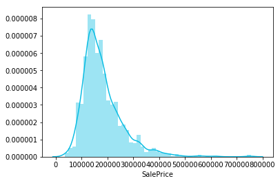

```python
#histogram
sns.distplot(train_data['SalePrice'], color='#0abde3');
```

```python
print("Skewness: %f" % train_data['SalePrice'].skew())
print("Our data is skewed to the right, which is pretty intuitive, since we will have more cheap that expensive houses.")
```

```
Skewness: 1.882876
Our data is skewed to the right, which is pretty intuitive, since we will have more cheap that expensive houses.
```

## Correlation matrix

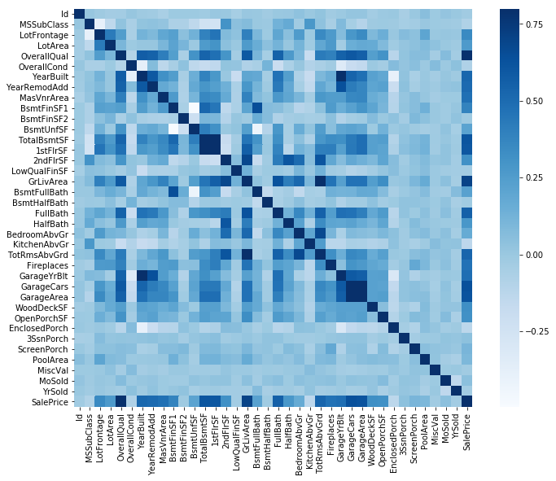

```python
corrmat = train_data.corr()
f, ax = plt.subplots(figsize=(12, 9))
sns.heatmap(corrmat, vmax=.8, square=True, cmap='Blues');
```

To understand variables that are connected to the price of sale the most, let's plot 5 of them with largest correlaton with SalePrice.

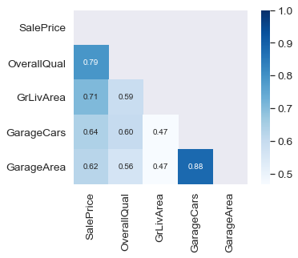

```python
#saleprice correlation matrix
k = 5 #number of variables for heatmap
cols = corrmat.nlargest(k, 'SalePrice')['SalePrice'].index
cm = np.corrcoef(train_data[cols].values.T)
sns.set(font_scale=1.25)
# Generate a mask for the upper triangle
mask = np.zeros_like(cm, dtype=np.bool)
mask[np.triu_indices_from(mask)] = True

hm = sns.heatmap(cm, mask=mask, cbar=True, annot=True, square=True, fmt='.2f', annot_kws={'size': 10}, yticklabels=cols.values, xticklabels=cols.values, cmap='Blues')
plt.show()
```

The results are not surprising: the better is the quality of the house, the bigger living area is, the more place there is in the garage, the more expensive the house is.

### Let's visualize the distribution of these important variables with respect to SalePrice.

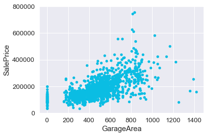

```python
var = 'GarageArea'
data = pd.concat([train_data['SalePrice'], train_data[var]], axis=1)
data.plot.scatter(x=var, y='SalePrice', ylim=(0,800000), color="#0abde3");
```

It can be seen that all houses without garage are cheaper than 200 000, and then the price generally increases with increasing garage area. Though, we noticed some outliars, with huge garage area, but low price.

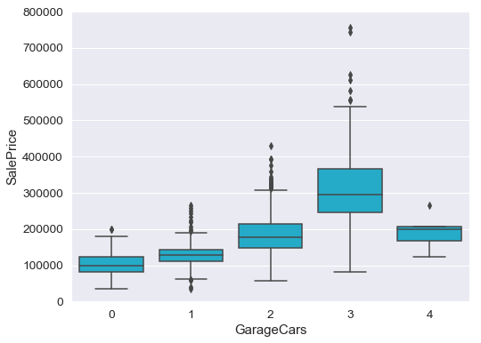

```python
var = 'GarageCars'
data = pd.concat([train_data['SalePrice'], train_data[var]], axis=1)
f, ax = plt.subplots(figsize=(8, 6))
fig = sns.boxplot(x=var, y="SalePrice", data=data, color='#0abde3')
fig.axis(ymin=0, ymax=800000);
```

The boxplot of GarageCars looks interesting - seems that data is not very centered around the mean(there are a lot of cars on the whiskers), and prices of houses with 4 places for cars are simmilar to those with 2 cars. These could include same houses who were outliars in the previous plot.

Of course, number of cars in garage are strongly correlated with size of a garage(0.88), so let's take a look at how they correspond to each other.

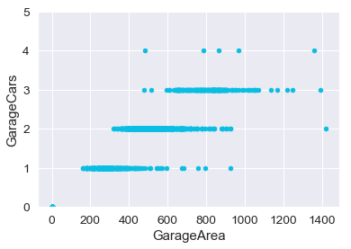

```python
var = 'GarageArea'
data = pd.concat([train_data['GarageCars'], train_data[var]], axis=1)
data.plot.scatter(x=var, y='GarageCars', ylim=(0,5), color="#0abde3");
```

Let's move on to the exploration of Gliving area - second most correlated with our target variable. Plot shows almost linear relationship, but for some extremely big houses(area bigger than 4000 square feet), trend is not visible. 2 houses are extremely exspensive, other 2 - extremely cheap.

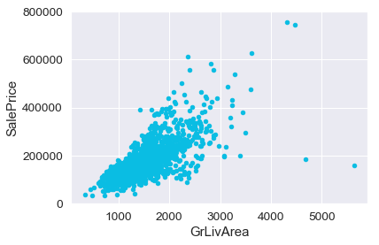

```python
var = 'GrLivArea'
data = pd.concat([train_data['SalePrice'], train_data[var]], axis=1)
data.plot.scatter(x=var, y='SalePrice', ylim=(0,800000), color="#0abde3");
```

Relationship between general quality and its sale price is linear - people are willing to pay more for the better houses.

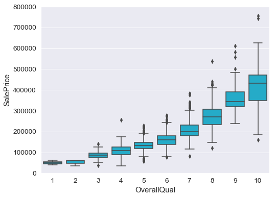

```python
var = 'OverallQual'
data = pd.concat([train_data['SalePrice'], train_data[var]], axis=1)
f, ax = plt.subplots(figsize=(8, 6))
fig = sns.boxplot(x=var, y="SalePrice", data=data, color='#0abde3')
fig.axis(ymin=0, ymax=800000);
```

## Treating missing data

Now it's time to look at the data that cannot be seen - NA's in dataset

```python
#missing data
total = train_data.isnull().sum().sort_values(ascending=False)
percent = (train_data.isnull().sum()/train_data.isnull().count()).sort_values(ascending=False)
missing_data = pd.concat([total, percent], axis=1, keys=['Total', 'Percent'])
missing_data.head(19)
```

|  | Total | Percent |
| --- | --- | --- |
| PoolQC | 1453 | 0.995205 |
| MiscFeature | 1406 | 0.963014 |
| Alley | 1369 | 0.937671 |
| Fence | 1179 | 0.807534 |
| FireplaceQu | 690 | 0.472603 |
| LotFrontage | 259 | 0.177397 |
| GarageCond | 81 | 0.055479 |
| GarageType | 81 | 0.055479 |
| GarageYrBlt | 81 | 0.055479 |
| GarageFinish | 81 | 0.055479 |
| GarageQual | 81 | 0.055479 |
| BsmtExposure | 38 | 0.026027 |
| BsmtFinType2 | 38 | 0.026027 |
| BsmtFinType1 | 37 | 0.025342 |
| BsmtCond | 37 | 0.025342 |
| BsmtQual | 37 | 0.025342 |
| MasVnrArea | 8 | 0.005479 |
| MasVnrType | 8 | 0.005479 |
| Electrical | 1 | 0.000685 |

There are 19 columns with missing data. When looking closely, it doesn't seem that they are very important when deciding on buying a house - Pool, MiscFeature, Fireplace Quality, type of masonry(really?).

Then, there is a lot of missing data for information on a garage, but the most important information about garage is conveyed in GarageCars and GarageArea variables. Same with basement - there is a variable BasementTotalSF, which is intuitively more important than FinType or Exposure, and strongly correlated with all of them. So,if ve delete these variables, will we miss them? We don't think so. Finally, column "Electrical" has missing value in only 1 observation, so we'll delete this observation and keep the variable.

```python
train_data = train_data.drop((missing_data[missing_data['Total'] > 1]).index,1)
train_data = train_data.drop(train_data.loc[train_data['Electrical'].isnull()].index)
```

## Out liars!

Now,we need to look for outliars and treat them how they deserve to be treated, because thay can effect the quality of our models. To identify them, we'll first standardize the data, making its mean equal to 0 and variance equal to 1.

```python
#standardizing data
saleprice_scaled = StandardScaler().fit_transform(train_data['SalePrice'][:,np.newaxis]);
low_range = saleprice_scaled[saleprice_scaled[:,0].argsort()][:10]
high_range= saleprice_scaled[saleprice_scaled[:,0].argsort()][-10:]
print('LOW OUTLIERS:')
print(low_range)
print('\nHIGH OUTLIERS(CRAZY EXPENSIVE):')
print(high_range)
```

```
LOW OUTLIERS:
[[-1.83820775]
 [-1.83303414]
 [-1.80044422]
 [-1.78282123]
 [-1.77400974]
 [-1.62295562]
 [-1.6166617 ]
 [-1.58519209]
 [-1.58519209]
 [-1.57269236]]

HIGH OUTLIERS(CRAZY EXPENSIVE):
[[3.82758058]
 [4.0395221 ]
 [4.49473628]
 [4.70872962]
 [4.728631  ]
 [5.06034585]
 [5.42191907]
 [5.58987866]
 [7.10041987]
 [7.22629831]]
```

Let's return to the important variables, identify outliars in their relationship with SalePrice, and kick them out.

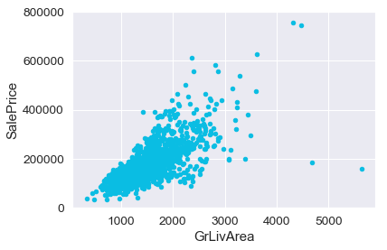

```python
var = 'GrLivArea'
data = pd.concat([train_data['SalePrice'], train_data[var]], axis=1)
data.plot.scatter(x=var, y='SalePrice', ylim=(0,800000), color="#0abde3");
```

The outliars we noticed before(extremely big and unusually cheap or expensive) will be deleted.

```python
train_data.loc[train_data['GrLivArea'] > 4500]
```

|  | Id | MSSubClass | MSZoning | LotArea | Street | LotShape | LandContour | Utilities | LotConfig | LandSlope | ... | EnclosedPorch | 3SsnPorch | ScreenPorch | PoolArea | MiscVal | MoSold | YrSold | SaleType | SaleCondition | SalePrice |
| --- | --- | --- | --- | --- | --- | --- | --- | --- | --- | --- | --- | --- | --- | --- | --- | --- | --- | --- | --- | --- | --- |
| 523 | 524 | 60 | RL | 40094 | Pave | IR1 | Bnk | AllPub | Inside | Gtl | ... | 0 | 0 | 0 | 0 | 0 | 10 | 2007 | New | Partial | 184750 |
| 1298 | 1299 | 60 | RL | 63887 | Pave | IR3 | Bnk | AllPub | Corner | Gtl | ... | 0 | 0 | 0 | 480 | 0 | 1 | 2008 | New | Partial | 160000 |

2 rows × 63 columns

```python
train_data = train_data.drop(train_data[train_data['Id'] == 1299].index)
train_data = train_data.drop(train_data[train_data['Id'] == 524].index)
```

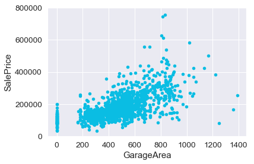

```python
var = 'GarageArea'
data = pd.concat([train_data['SalePrice'], train_data[var]], axis=1)
data.plot.scatter(x=var, y='SalePrice', ylim=(0,800000), color="#0abde3");
```

We'll also delete unusually cheap houses with big GarageArea(more than 1200 sqft)

```python
train_data.loc[train_data['GarageArea'] > 1220]
```

|  | Id | MSSubClass | MSZoning | LotArea | Street | LotShape | LandContour | Utilities | LotConfig | LandSlope | ... | EnclosedPorch | 3SsnPorch | ScreenPorch | PoolArea | MiscVal | MoSold | YrSold | SaleType | SaleCondition | SalePrice |
| --- | --- | --- | --- | --- | --- | --- | --- | --- | --- | --- | --- | --- | --- | --- | --- | --- | --- | --- | --- | --- | --- |
| 581 | 582 | 20 | RL | 12704 | Pave | Reg | Lvl | AllPub | Inside | Gtl | ... | 0 | 0 | 0 | 0 | 0 | 8 | 2009 | New | Partial | 253293 |
| 1061 | 1062 | 30 | C (all) | 18000 | Grvl | Reg | Low | AllPub | Inside | Gtl | ... | 0 | 0 | 0 | 0 | 560 | 8 | 2008 | ConLD | Normal | 81000 |
| 1190 | 1191 | 190 | RL | 32463 | Pave | Reg | Low | AllPub | Inside | Mod | ... | 0 | 0 | 0 | 0 | 0 | 3 | 2007 | WD | Normal | 168000 |

3 rows × 63 columns

```python
train_data = train_data.drop(train_data[train_data['Id'] == 582].index)
train_data = train_data.drop(train_data[train_data['Id'] == 1062].index)
train_data = train_data.drop(train_data[train_data['Id'] == 1191].index)
train_data = train_data.drop(train_data[train_data['Id'] == 1298].index)
```

## In search for normality

We remember that distribution of SalePrice is skewed to the right. Lets see how far away it is from the normal.

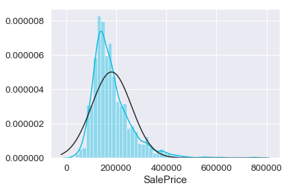

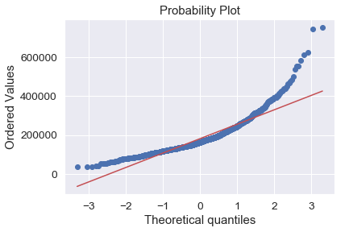

```python
#histogram
sns.distplot(train_data['SalePrice'], color='#0abde3', fit = norm);
fig = plt.figure()
res = stats.probplot(train_data['SalePrice'], plot=plt)
```

Ok, 'SalePrice' is not normal. It shows 'peakedness', positive skewness and does not follow the diagonal line. To "make things normal", we'll use log transformation. Plots below illustrate the transformed data, which is much closer to normall distribution.

```python
#applying log transformation
train_data['SalePrice'] = np.log(train_data['SalePrice'])
```

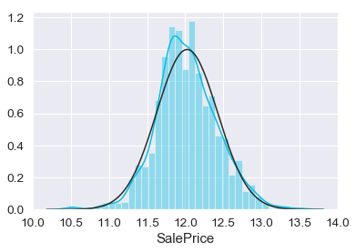

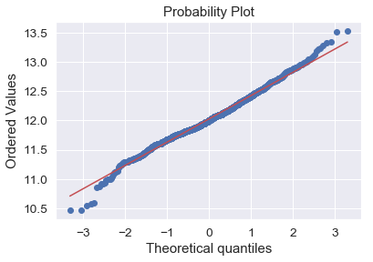

```python
#transformed histogram and normal probability plot
sns.distplot(train_data['SalePrice'], fit=norm,  color='#0abde3');
fig = plt.figure()
res = stats.probplot(train_data['SalePrice'], plot=plt)
```

Now, let's check the distribution of GrLivingArea.

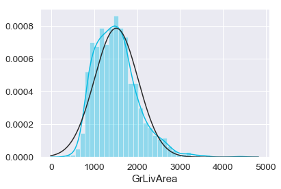

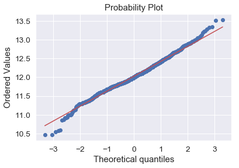

```python
#histogram
sns.distplot(train_data['GrLivArea'], color='#0abde3', fit = norm);
fig = plt.figure()
res = stats.probplot(train_data['SalePrice'], plot=plt)
```

Tastes like skewness...let's apply the powerful spell again. Avada Kedavra!(Log Transformation)

```python
train_data['GrLivArea'] = np.log(train_data['GrLivArea'])
```

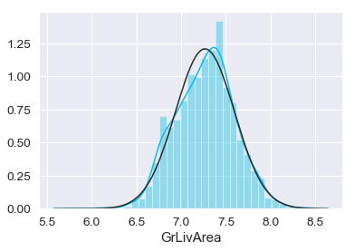

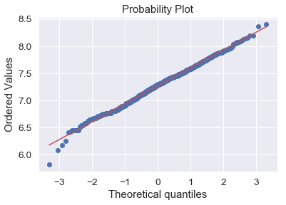

```python
#transformed histogram and normal probability plot
sns.distplot(train_data['GrLivArea'], fit=norm, color='#0abde3');
fig = plt.figure()
res = stats.probplot(train_data['GrLivArea'], plot=plt)
```

## The finish line of data exploration

Our data has a lot of categorical variables. To include each category in our models, we'll make dumies for them.

```python
train_data = pd.get_dummies(train_data)
```

# Time for models!

We decided to start with the most simple approach - linear model, that will include all of our columns.

```python
from pandas import DataFrame
from sklearn import linear_model
import statsmodels.api as sm

df = train_data
X =df.loc[:, df.columns != 'SalePrice']

Y = df['SalePrice']
# with sklearn
regr = linear_model.LinearRegression()
regr.fit(X, Y)
```

```
LinearRegression(copy_X=True, fit_intercept=True, n_jobs=None,
         normalize=False)
```

### Here are the results of this model:

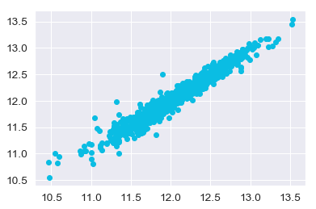

```python
pred = regr.predict(X)
plt.scatter(Y,pred, color='#0abde3')
```

```python
from sklearn.metrics import mean_squared_error

rms = (mean_squared_error(Y, pred))
```

Mean square error for this model:

```python
rms
```

```
0.00865135798968965
```

Looks good? Don't be fooled! SPOILER: the model is overfitted and will not deliver the same result on actual test data!

```python
print('Intercept: \n', regr.intercept_)
print('Coefficients: \n', regr.coef_)

model = sm.OLS(Y, X).fit()
print_model = model.summary()
print(print_model)
```

```
Intercept:
 6.727108137488771
Coefficients:
 [-6.13459581e-06 -2.17895700e-04  3.11612353e-06  4.10934794e-02
  3.90615204e-02  2.03401478e-03  7.11825468e-04  6.99449783e-05
  2.62263114e-05 -7.73231057e-06  8.84403955e-05  8.68959053e-05
  1.15765543e-04  6.64798641e-05  3.00354583e-01  2.51839280e-02
  3.82930496e-03  1.25934829e-02  1.43176804e-02 -5.70580909e-03
 -6.72467205e-02  3.29403252e-03  1.90584740e-02  2.70675818e-02
  1.05873270e-04  9.58715732e-05  1.03197539e-04  1.03747792e-04
  1.15096064e-04  2.55535863e-04  1.67441893e-04  3.39172747e-07
 -1.02513417e-03 -1.78374254e-03 -3.24928566e-01  1.06912641e-01
  8.02296960e-02  8.85821485e-02  4.92040805e-02 -8.61208757e-02
  8.61208757e-02 -9.08153089e-03  1.72855691e-02 -4.97693856e-04
 -7.70634438e-03 -3.37399635e-03  2.19895951e-02 -2.73058098e-02
  8.69021105e-03  9.40254375e-02 -9.40254375e-02  2.17010488e-02
  4.09525740e-02 -1.20271300e-02 -5.97330897e-02  9.10659689e-03
  4.18084992e-02  8.54226626e-02 -1.27231162e-01  1.37960596e-04
 -3.72827738e-02 -4.01266532e-02  3.01240909e-02  1.12080192e-02
 -9.03152680e-03  1.08073064e-01 -6.35346562e-02 -1.63148289e-02
 -1.77861248e-02 -1.35421682e-01 -4.76549832e-02 -2.59917563e-02
  1.67151009e-02 -3.94803311e-02  5.28548819e-02  7.55314164e-02
 -4.17251357e-02  1.03860579e-03 -1.71435598e-02 -3.89750203e-03
  2.45986182e-02  1.24477961e-01  7.82633995e-03  4.28054554e-02
 -3.20427589e-02 -9.70112358e-03  4.33781185e-02  1.34913917e-02
  3.91474686e-02 -8.69825416e-02  5.06272613e-03 -3.14604967e-02
  5.91072159e-02  1.16002057e-02  1.10497744e-01  8.85017551e-02
  2.09987148e-01 -9.48490828e-02 -4.30697193e-01  6.58851351e-03
  9.83709091e-02  8.21524641e-03  4.92759557e-02  5.78127543e-03
 -5.16538316e-02 -1.16186459e-02 -1.66162970e-02  4.66486341e-02
  1.89938248e-03 -8.30916577e-02  1.64364545e-02 -3.70380569e-02
  4.55566747e-02  2.62048658e-02 -5.55489661e-02 -8.45428380e-02
 -9.23327764e-02 -8.02586080e-02 -3.16858609e-02  3.44369049e-01
 -1.12741269e-01  3.10866433e-01  1.39566989e-01 -7.50970373e-02
 -8.79325707e-02 -1.84634044e-01  9.97149870e-03  1.08583528e-02
  3.40715412e-03 -1.96090430e-01  1.05916055e-01 -4.24547242e-02
 -7.20777840e-02  2.34023688e-02 -5.32807942e-02  7.08459573e-02
  8.04224773e-03  7.24677347e-02  4.04729184e-02  6.63612104e-03
 -7.80552442e-03  2.96603471e-02 -2.77811722e-03  7.67416171e-03
  2.20597081e-02 -5.04649869e-02 -4.24547242e-02  1.16541943e-01
```

[output cut: 248 more lines]

```
SaleCondition_Alloca      0.2040      0.128      1.590      0.112      -0.048       0.456
SaleCondition_Family      0.1603      0.126      1.277      0.202      -0.086       0.407
SaleCondition_Normal      0.2154      0.125      1.720      0.086      -0.030       0.461
SaleCondition_Partial     0.1512      0.136      1.114      0.266      -0.115       0.418
==============================================================================
Omnibus:                      312.950   Durbin-Watson:                   1.864
Prob(Omnibus):                  0.000   Jarque-Bera (JB):             2270.068
Skew:                          -0.803   Prob(JB):                         0.00
Kurtosis:                       8.909   Cond. No.                     1.34e+16
==============================================================================

Warnings:
[1] Standard Errors assume that the covariance matrix of the errors is correctly specified.
[2] The smallest eigenvalue is 1.74e-21. This might indicate that there are
strong multicollinearity problems or that the design matrix is singular.
```

R-squared of our model is ~ 96%, which is way too high and indicates that our model is overfitted. Also, there are some violations of OLS assumptions (multicolinearity!). Let's try to improve this model by looking at the t-value and picking only those values, that are statistically significant.

### "Improved" linear model

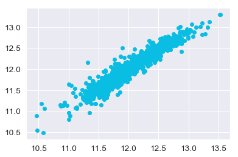

```python
df = train_data
X = df[['LotArea', 'OverallQual', 'OverallCond', 'YearBuilt', 'YearRemodAdd', 'BsmtFinSF1', 'TotalBsmtSF', 'GrLivArea', 'BsmtFullBath','KitchenAbvGr', 'Fireplaces', 'GarageArea', 'WoodDeckSF', 'OpenPorchSF', 'MSZoning_C (all)', 'Neighborhood_Crawfor']]
Y = df['SalePrice']

regr = linear_model.LinearRegression()
regr.fit(X, Y)

predictions = regr.predict(X)
plt.scatter(Y,predictions, color='#0abde3')
```

```python
print('Intercept: \n', regr.intercept_)
print('Coefficients: \n', regr.coef_)

model = sm.OLS(Y, X).fit()
print_model = model.summary()
print(print_model)
```

```
Intercept:
 -0.042391838862528175
Coefficients:
 [ 2.66301267e-06  6.92251987e-02  4.51971405e-02  2.88382510e-03
  1.17979137e-03  7.84617747e-05  1.28691292e-04  4.27139557e-01
  1.97491093e-02 -8.78288026e-02  3.16266033e-02  2.39993404e-04
  8.08245904e-05  1.23352817e-04 -3.44602603e-01  1.42914774e-01]
                            OLS Regression Results
==============================================================================
Dep. Variable:              SalePrice   R-squared:                       1.000
Model:                            OLS   Adj. R-squared:                  1.000
Method:                 Least Squares   F-statistic:                 8.621e+05
Date:                Sat, 18 May 2019   Prob (F-statistic):               0.00
Time:                        18:39:35   Log-Likelihood:                 985.65
No. Observations:                1453   AIC:                            -1939.
Df Residuals:                    1437   BIC:                            -1855.
Df Model:                          16
Covariance Type:            nonrobust
========================================================================================
                           coef    std err          t      P>|t|      [0.025      0.975]
----------------------------------------------------------------------------------------
LotArea               2.662e-06   3.54e-07      7.524      0.000    1.97e-06    3.36e-06
OverallQual              0.0694      0.004     19.282      0.000       0.062       0.076
OverallCond              0.0452      0.004     12.671      0.000       0.038       0.052
YearBuilt                0.0029      0.000     17.163      0.000       0.003       0.003
YearRemodAdd             0.0012      0.000      6.372      0.000       0.001       0.002
BsmtFinSF1            7.844e-05    1.1e-05      7.147      0.000    5.69e-05      0.0001
TotalBsmtSF              0.0001   1.07e-05     12.010      0.000       0.000       0.000
GrLivArea                0.4267      0.014     29.653      0.000       0.398       0.455
BsmtFullBath             0.0198      0.008      2.338      0.020       0.003       0.036
KitchenAbvGr            -0.0879      0.016     -5.485      0.000      -0.119      -0.056
Fireplaces               0.0316      0.006      5.128      0.000       0.020       0.044
GarageArea               0.0002   2.03e-05     11.860      0.000       0.000       0.000
WoodDeckSF            8.121e-05   2.77e-05      2.930      0.003    2.68e-05       0.000
OpenPorchSF              0.0001   5.31e-05      2.333      0.020    1.97e-05       0.000
MSZoning_C (all)        -0.3449      0.042     -8.202      0.000      -0.427      -0.262
Neighborhood_Crawfor     0.1428      0.019      7.656      0.000       0.106       0.179
==============================================================================
Omnibus:                      251.431   Durbin-Watson:                   1.931
Prob(Omnibus):                  0.000   Jarque-Bera (JB):             1149.606
Skew:                          -0.744   Prob(JB):                    2.32e-250
Kurtosis:                       7.096   Cond. No.                     1.89e+05
==============================================================================

Warnings:
[1] Standard Errors assume that the covariance matrix of the errors is correctly specified.
[2] The condition number is large, 1.89e+05. This might indicate that there are
strong multicollinearity or other numerical problems.
```

### It's a failure again - R^2 of 100%? :( The model is overfitted, so let's move on to smarter approaches!

## Ridge regression

One way to avoid overfitteng is to use Ridge regression. With just a small bias of estimation in train data, we can better the estimation of test data and minimize Variance, as well as provide better long-term predictions. BAM! Ridge regression minimizes sum of squared residuals + alpha*(all_coefficient_slopes^2).

```python
from sklearn.linear_model import Ridge, RidgeCV, ElasticNet, LassoCV, LassoLarsCV
from sklearn.model_selection import cross_val_score

df = train_data
X =df.loc[:, df.columns != 'SalePrice']
Y = df['SalePrice']

def rmse_cv(model):
    rmse= np.sqrt(-cross_val_score(model, X, Y, scoring="neg_mean_squared_error", cv = 5))
    return(rmse)

model_ridge = Ridge()

alphas = [0.05, 0.1, 0.3, 1, 3, 5, 10, 15, 30, 50, 75]
cv_ridge = [rmse_cv(Ridge(alpha = alpha)).mean()
            for alpha in alphas]
```

Using cross-validation, we can see, that rmse is minimized when the index of of alpha is:

```python
cv_ridge.index(min(cv_ridge))
```

```
6
```

And the value of this alpha is:

```python
alphas[6]
```

```
10
```

### Visual representation of how, depending on different alphas, rmse changes:

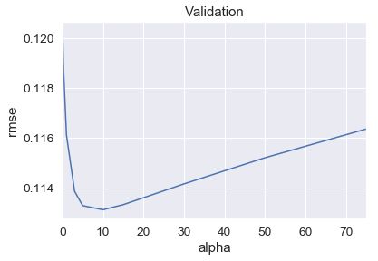

```python
cv_ridge = pd.Series(cv_ridge, index = alphas)
cv_ridge.plot(title = "Validation")
plt.xlabel("alpha")
plt.ylabel("rmse")
```

So, our minimum error is:

```python
min(cv_ridge)
```

```
0.11313601801315878
```

You wanted estimation with Ridge? Not yet (today). Let's check the RMSE of Lasso Regression.

## Lasso regression - more exciting results!

The main difference from Ridge regression is, that we minimize ssr + alpha* ABSOLUTE VALUE of all coefficient slopes. When Ridge can make the slope of silly parameters only assimptotically close to zero, Lasso can ACTUALLY make them zero. THis is useful in our case, when we are not sure whether all the variables in our dataset significantly influence price.

```python
alphas = [1, 0.1, 0.001, 0.0005]

cv_lasso = [rmse_cv(LassoCV(alphas = alphas)).mean()
            for alpha in alphas]

model_lasso = LassoCV(alphas = alphas).fit(X, Y)
```

Choosing alpha that minimizes penalty function (ssr + alpha* ABSOLUTE VALUE of all coefficient slopes):

```python
cv_lasso.index(min(cv_lasso))
```

```
0
```

```python
alphas[0]
```

```
1
```

```python
coef = pd.Series(model_lasso.coef_, index = X.columns)
print("Lasso picked " + str(sum(coef != 0)) + " variables and eliminated the other " +  str(sum(coef == 0)) + " variables")
```

```
Lasso picked 90 variables and eliminated the other 130 variables
```

```python
min(cv_lasso)
```

```
0.11176771421344953
```

Since this mse is less than in Ridge, we will use Lasso model for predicting prices.

[figure not shown]

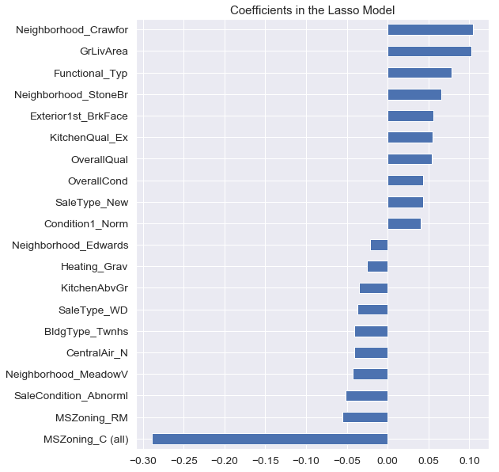

```python
import matplotlib
imp_coef = pd.concat([coef.sort_values().head(10),
                     coef.sort_values().tail(10)])

matplotlib.rcParams['figure.figsize'] = (8.0, 10.0)
imp_coef.plot(kind = "barh")
plt.title("Coefficients in the Lasso Model")
```

```
'c' argument looks like a single numeric RGB or RGBA sequence, which should be avoided as value-mapping will have precedence in case its length matches with 'x' & 'y'.  Please use a 2-D array with a single row if you really want to specify the same RGB or RGBA value for all points.
```

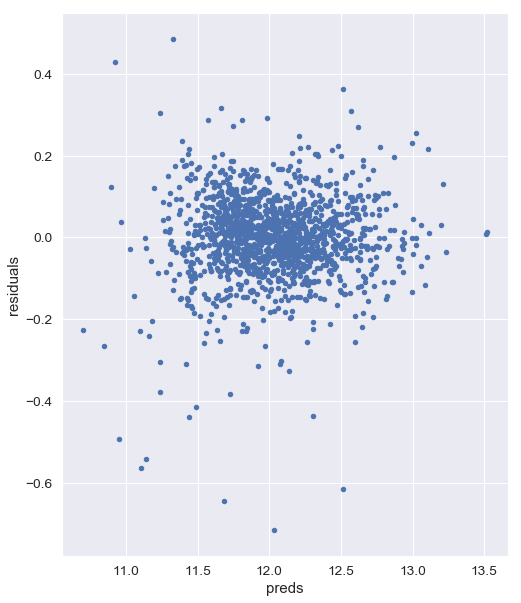

```python
#let's look at the residuals as well:

preds = pd.DataFrame({"preds":model_lasso.predict(X), "true":Y})
preds["residuals"] = preds["true"] - preds["preds"]
preds.plot(x = "preds", y = "residuals",kind = "scatter")
#ignore the error:)
```

Looks great, they are mostly situated close to zero.

### This is how well does Lasso estimate prices on train data:

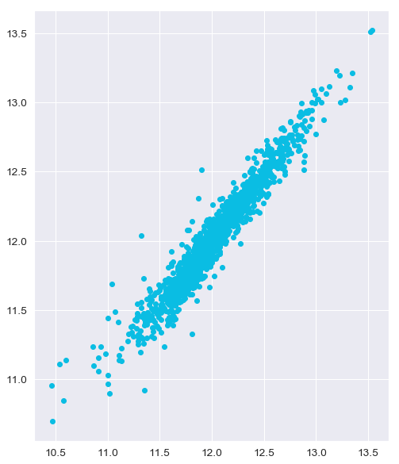

```python
predictions = model_lasso.predict(X)
plt.scatter(Y,predictions, color='#0abde3')
```

However, when we uploaded the predictions on test data using this model, we got not the best results:

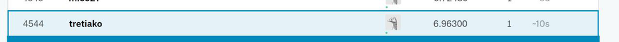

Our root mean squared logarithmic error is HUGE! And our position on the leaderbord is unfortunately not as huge. rather tiny. So, we decided to try one more approach.

## XGBoost

Xgboost is a machine learning model, whose objective function is to minimize

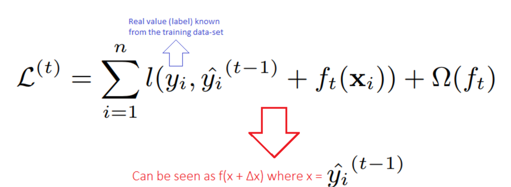

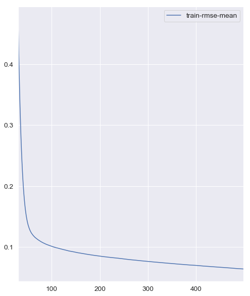

```python
import xgboost as xgb

dtrain = xgb.DMatrix(X, label = Y)


params = {"max_depth":2, "eta":0.1}
model = xgb.cv(params, dtrain,  num_boost_round=500, early_stopping_rounds=100)
# number of boosts corresponds to the number of trees built, and early-stopping_rounds is a signal to stop the training
#if the performance hasn't improved for N rounds

model.loc[30:,["train-rmse-mean"]].plot()
```

So, we see that minimumu error is at 500 iterations.

### Visualizing predictions made with XGboost

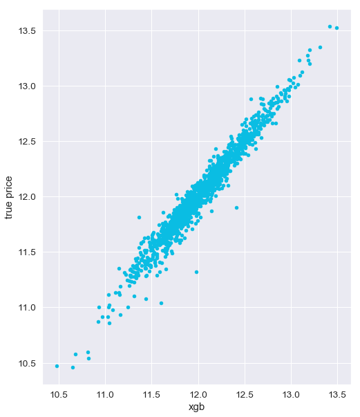

```python
from numpy import log
model_xgb = xgb.XGBRegressor(n_estimators=360, max_depth=2, learning_rate=0.1) #the params were tuned using xgb.cv
model_xgb.fit(X, Y)

xgb_preds = np.expm1(model_xgb.predict(X))


predictions = pd.DataFrame({"xgb":log(xgb_preds), "true price":Y})
predictions.plot(x = "xgb", y = "true price", kind = "scatter", color='#0abde3')
```

```python
rms = (mean_squared_error(Y, predictions['xgb']))
rms
```

```
0.006478997000553658
```

```python
original = X.columns
data = pd.read_csv('C:/Users/trety/Downloads/test.csv')
raw = pd.read_csv('C:/Users/trety/Downloads/train.csv')
raw = raw.drop(columns='SalePrice')
result = raw.append(data)
result = pd.get_dummies(result)
data = result[result.Id > 1460]
print(data.shape)
new=data.columns


for col in new:
    if col not in original:
        data=data.drop(columns=[col],errors='ignore')

#Replace using median
data['BsmtFinSF1'].fillna(data['BsmtFinSF1'].median(), inplace=True)
data['BsmtFinSF2'].fillna(data['BsmtFinSF2'].median(), inplace=True)
data['BsmtUnfSF'].fillna(data['BsmtUnfSF'].median(), inplace=True)
data['TotalBsmtSF'].fillna(data['TotalBsmtSF'].median(), inplace=True)
data['BsmtFullBath'].fillna(data['BsmtFullBath'].median(), inplace=True)
data['BsmtHalfBath'].fillna(data['BsmtHalfBath'].median(), inplace=True)
data['GarageCars'].fillna(data['GarageCars'].median(), inplace=True)
data['GarageArea'].fillna(data['GarageArea'].median(), inplace=True)


xgb_preds = model_lasso.predict(data)
solution = pd.DataFrame({"id":data.Id, "SalePrice":xgb_preds})
solution.to_csv("C:\\Users\\trety\\Documents\\UCU\\2nd year\\econometrics\\solution.csv", index = False)
```

```
(1459, 289)
```

## RESULTS FROM KAGGLE

[figure not shown]

[figure not shown]

### Thank you for keeping up with us through this report.